# Exercise Sheet 5

1. Use DBSCAN to find clusters from nearby large cities around the world (metropolitan areas). A city with at least 50,000 inhabitants is considered large. The $\epsilon$-neighborhood of a city contains all adjacent cities with a Euclidean distance of 0.15 or less in latitude and longitude. A city is considered a core object of a conurbation if at least 8 cities are located in its $\epsilon$-neighborhood. For clustering, use the `maps::world.cities`dataset. Answer the following questions:
   1. How many clusters, core objects, border objects and noise objects are found by DBSCAN?
   2. How many cities does the largest cluster contain and in which country are the cities of the largest cluster located?
   3. Which three countries have the most cities in clusters?
   4. Are the Indian cities `Rajendranagar` und `Rajpur` (directly) density-reachable or density-connected?
   5. Are `Essen` und `Castrop-Rauxel` (directly) density-reachable or density-connected?
   6. Which cities are density-reachable from Bochum, but not directly density-reachable?

```r
# Solution for task 1...
library(maps)
library(fpc)
library(factoextra)
library(dplyr)
library(plyr)
library(dbscan)

DF = maps::world.cities

DF2= DF[which(DF[,3]>50000),]

DF2Subset <- DF2[, 4:5]
DB <- fpc::dbscan(DF2Subset, eps = 0.15, MinPts = 8)

DB
```

```
## dbscan Pts=8878 MinPts=8 eps=0.15
##           0   1 2  3  4 5 6  7  8  9 10 11 12 13 14 15 16 17 18 19 20 21 22 23
## border 8127  18 4  8  0 7 7 12  3  8 11 14  7  1  6  3  6  4  9  8  8  7  5  6
## seed      0  85 4  5 23 2 2 42  9  3 44 17  1 31 16 10  5 38  7  1  7  4  9  7
## total  8127 103 8 13 23 9 9 54 12 11 55 31  8 32 22 13 11 42 16  9 15 11 14 13
##        24 25 26 27 28 29 30 31 32 33 34 35 36 37 38 39 40 41
## border  0  8 12  6  7  9 10  6  9  8  4  9  8  8  7  7  7  7
## seed   10  2 11  6  1  6 13 14  5  1  6  2  2  2  1  1  1  1
## total  10 10 23 12  8 15 23 20 14  9 10 11 10 10  8  8  8  8
```

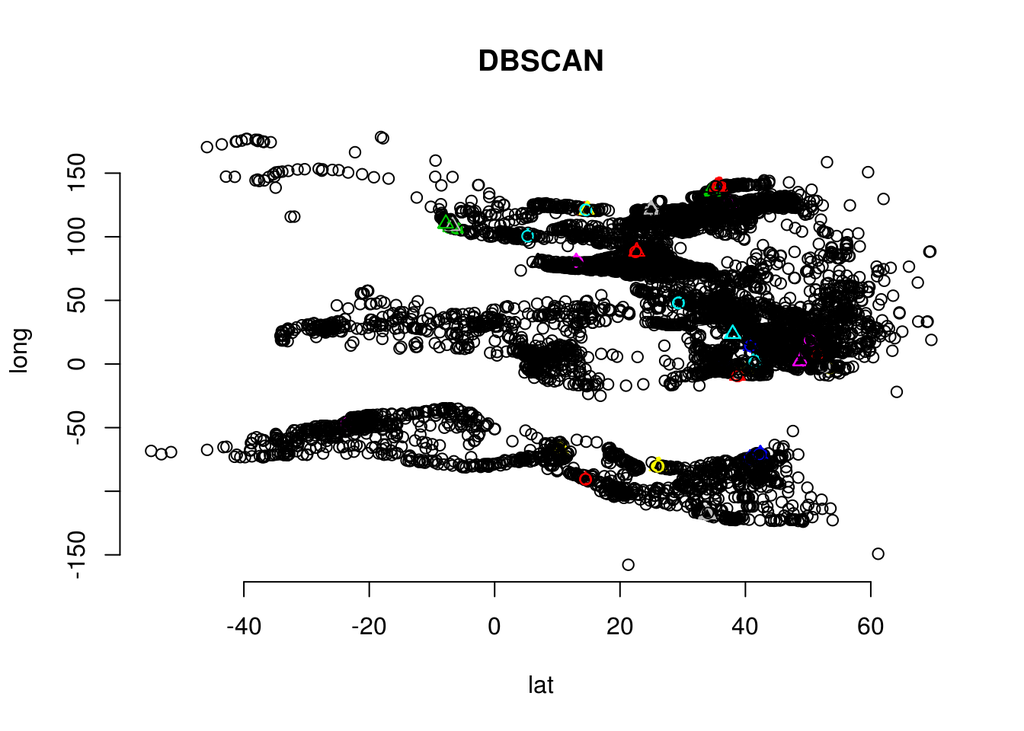

```r
plot(DB, DF2Subset, main = "DBSCAN", frame = FALSE)
```

```r
DF3 <- cbind(DF2,DB$cluster)

colnames(DF3)[colnames(DF3) == "DB$cluster"] <- "clusters"

  DF4 <- DF3[DF3$clusters!=0 , ]

DF5 <- ddply(DF4, .(clusters), transform, num.clusters= length(unique(name)))

DF5
```

```
##                          name country.etc      pop    lat    long capital
## 1                       Abiko       Japan   132577  35.88  140.03       0
## 2                        Ageo       Japan   220766  35.95  139.61       0
## 3                     Akiruno       Japan    82732  35.72  139.29       0
## 4                    Akishima       Japan   108172  35.70  139.36       0
## 5                       Asaka       Japan   129811  35.83  139.58       0
## 6                      Atsugi       Japan   231597  35.45  139.36       0
## 7                       Ayase       Japan    82921  35.44  139.43       0
## 8                       Chiba       Japan   926276  35.61  140.11       0
## 9                   Chigasaki       Japan   233850  35.33  139.41       0
## 10                      Chofu       Japan   214548  35.65  139.55       0
## 11                      Ebina       Japan   124920  35.47  139.42       0
## 12                      Fuchu       Japan   242730  35.67  139.48       0
## 13                     Fujimi       Japan   109524  35.87  139.54       0
## 14                   Fujisawa       Japan   397731  35.33  139.47       0
```

[output cut: 1489 more lines]

2. Given again be the dataset from task 2 of task sheet 3. This time use DBSCAN with $minPts=6$ for clustering. First determine a *suitable* value for $\epsilon$. Display the clustering in a scatter plot. Highlight cluster assignments and noise points in color. Compare and discuss the clustering of DBSCAN with the clustering of $k$-Means.

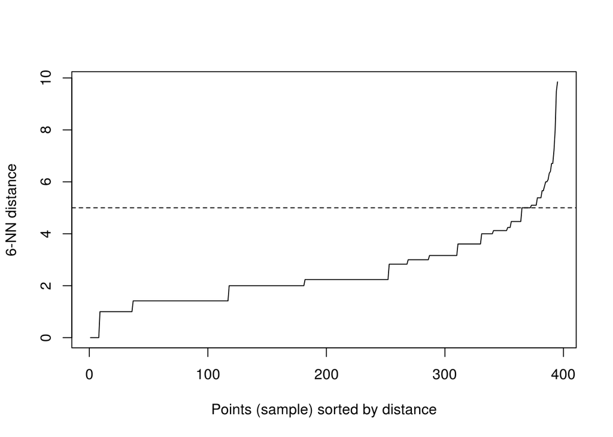

```r
# Solution for task 2...
DfStud <- read.csv(file = "/home/ravi/VersionControl/Git/VisualAnalytics/Exercise5/clustering-student-mat.csv")

dbscan::kNNdistplot(DfStud, k =  6)
abline(h = 5, lty = 2)
```

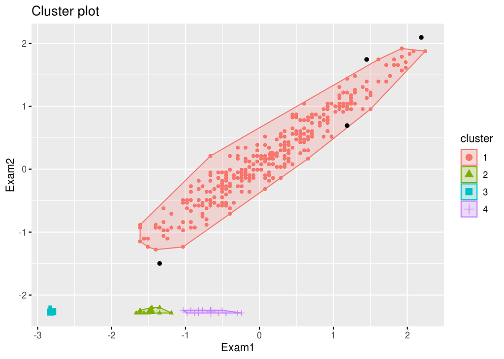

```r
DB <- fpc::dbscan(DfStud, eps = 5, MinPts = 6)


fviz_cluster(DB, DfStud, geom = "point")
```

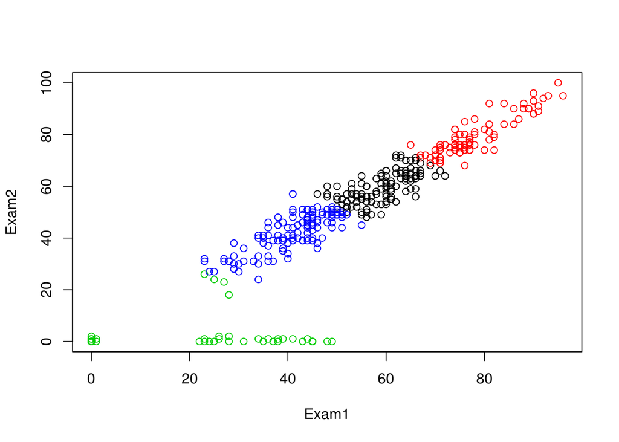

```r
k4 <- kmeans(DfStud, centers = 4, nstart = 25)
plot(DfStud,col=k4$cluster)
```

3. Given again, be the dataset from task 2 of task sheet 3. Use OPTICS to create a density reachability diagram for $minPts=6$. Extract a clustering for each $\textit{reachability-dist}=\{1,1.5,\ldots,5\}$ and display the result in a scatter plot, respectively. Highlight cluster assignments and noise points in color. Evaluate the change of the clustering result with increasing threshold for $\textit{reachability-dist}$ regarding the number of clusters as well as the number of core, border, and noise points.

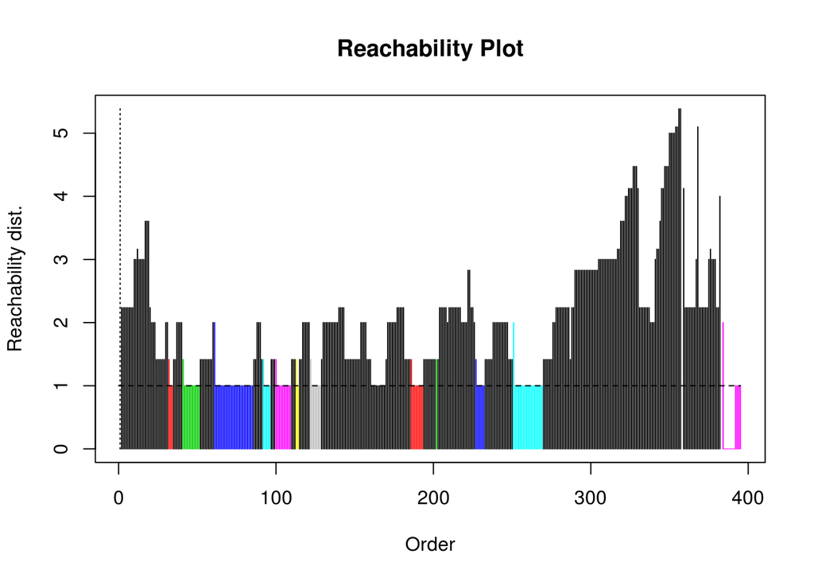

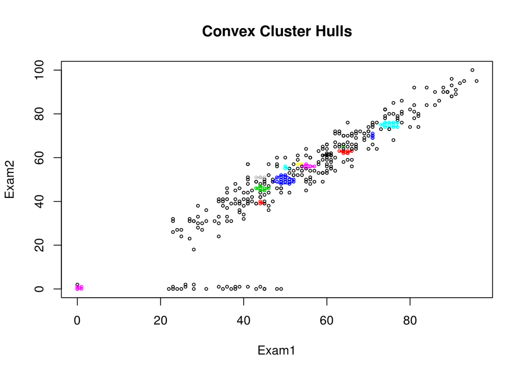

```
## OPTICS ordering/clustering for 395 objects.
## Parameters: minPts = 6, eps = 9.8488578017961, eps_cl = 1, xi = NA
## The clustering contains 13 cluster(s) and 276 noise points.
##
##   0   1   2   3   4   5   6   7   8   9  10  11  12  13
## 276   3  11  25   5  10   2   7  10   8   1   6  19  12
##
## Available fields: order, reachdist, coredist, predecessor, minPts, eps,
##                   eps_cl, xi, cluster
```

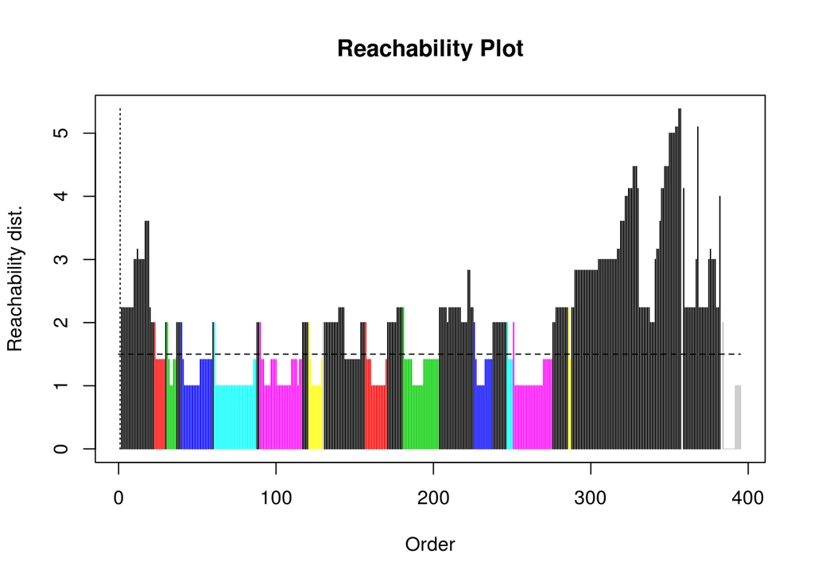

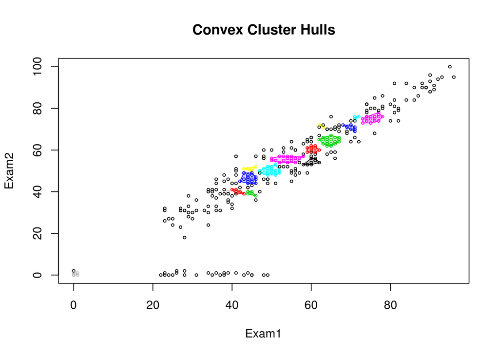

```
## OPTICS ordering/clustering for 395 objects.
## Parameters: minPts = 6, eps = 9.8488578017961, eps_cl = 1.5, xi = NA
## The clustering contains 15 cluster(s) and 195 noise points.
##
##   0   1   2   3   4   5   6   7   8   9  10  11  12  13  14  15
## 195   7   6  20  27  27   9   1  11  14  23  12   4  25   2  12
##
## Available fields: order, reachdist, coredist, predecessor, minPts, eps,
##                   eps_cl, xi, cluster
```

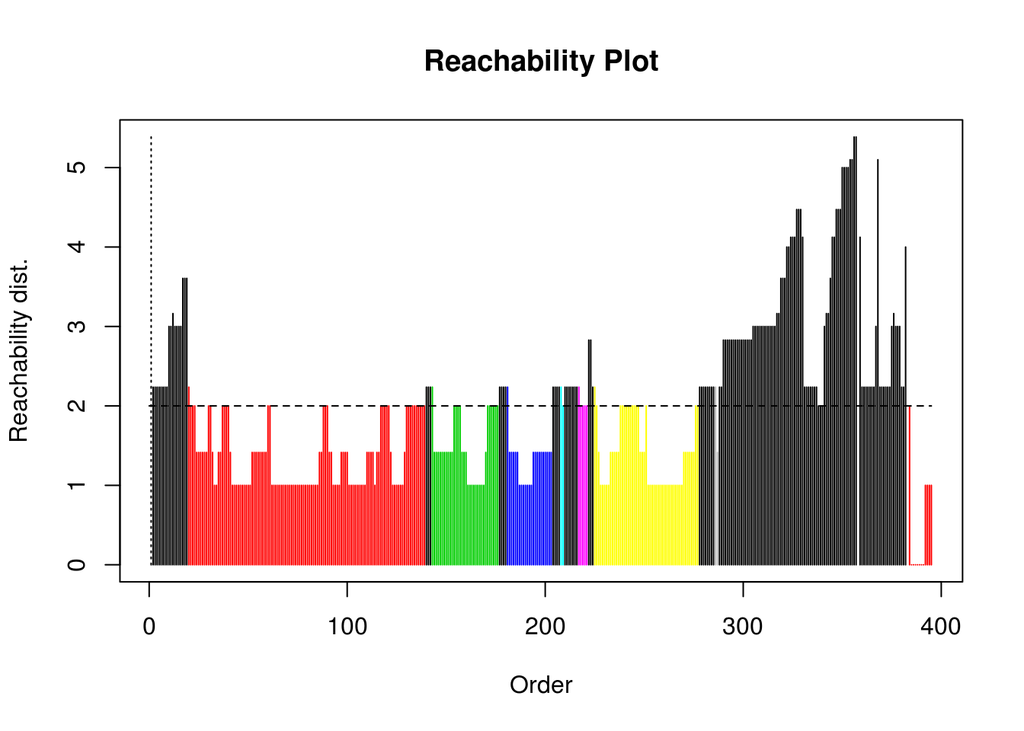

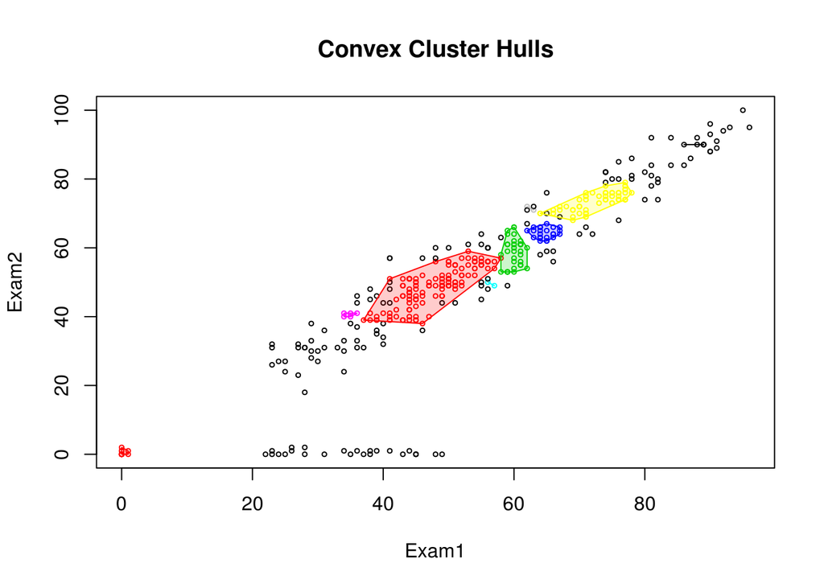

```
## OPTICS ordering/clustering for 395 objects.
## Parameters: minPts = 6, eps = 9.8488578017961, eps_cl = 2, xi = NA
## The clustering contains 9 cluster(s) and 139 noise points.
##
##   0   1   2   3   4   5   6   7   8   9
## 139 120  34  23   2   5  53   2   4  13
##
## Available fields: order, reachdist, coredist, predecessor, minPts, eps,
##                   eps_cl, xi, cluster
```

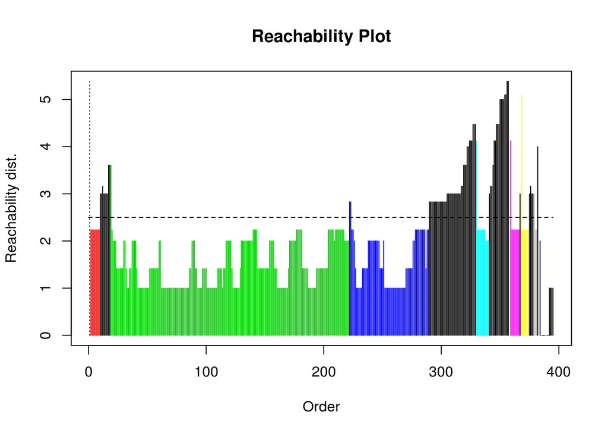

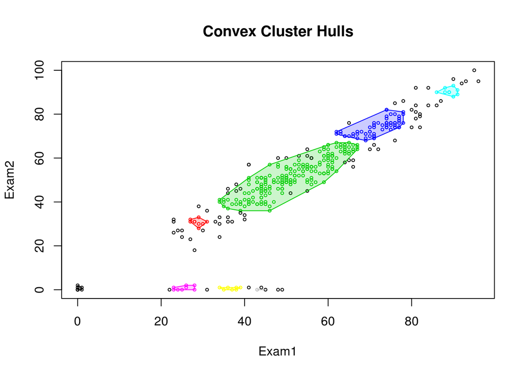

```
## OPTICS ordering/clustering for 395 objects.
## Parameters: minPts = 6, eps = 9.8488578017961, eps_cl = 2.5, xi = NA
## The clustering contains 8 cluster(s) and 74 noise points.
##
##   0   1   2   3   4   5   6   7   8
##  74   9 203  67  11   8   7   3  13
##
## Available fields: order, reachdist, coredist, predecessor, minPts, eps,
##                   eps_cl, xi, cluster
```

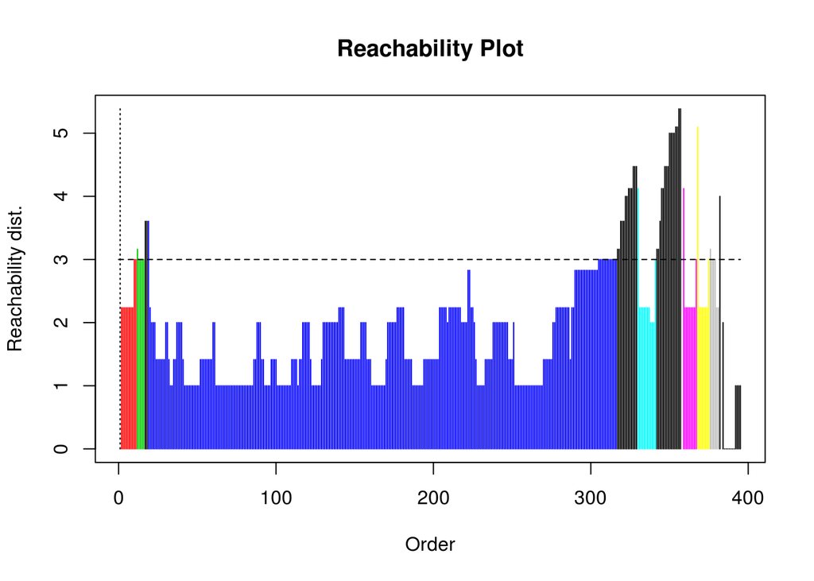

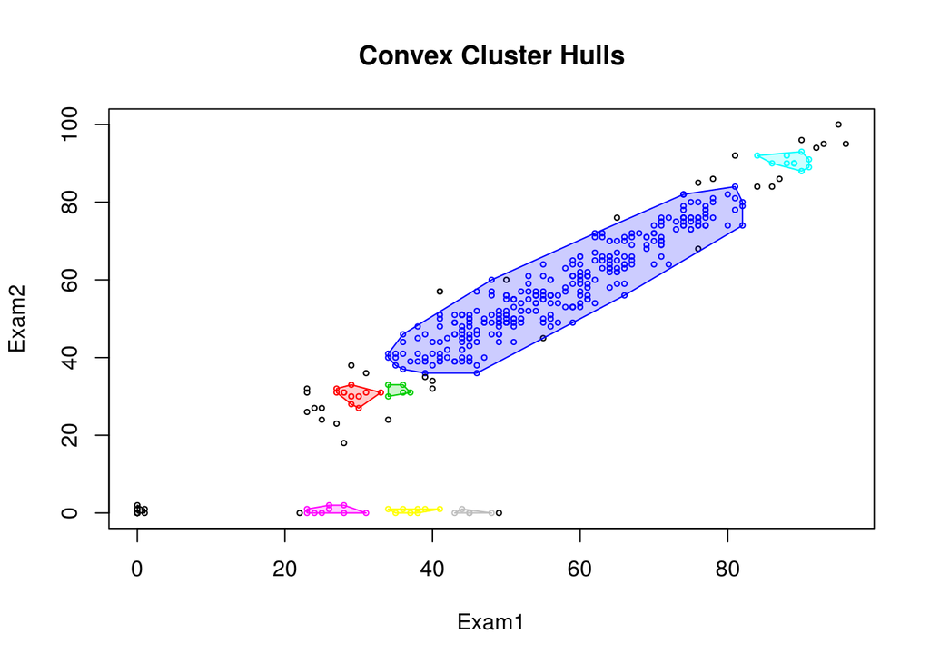

```
## OPTICS ordering/clustering for 395 objects.
## Parameters: minPts = 6, eps = 9.8488578017961, eps_cl = 3, xi = NA
## The clustering contains 8 cluster(s) and 33 noise points.
##
##   0   1   2   3   4   5   6   7   8
##  33  11   5 298  12   9   8   6  13
##
## Available fields: order, reachdist, coredist, predecessor, minPts, eps,
##                   eps_cl, xi, cluster
```

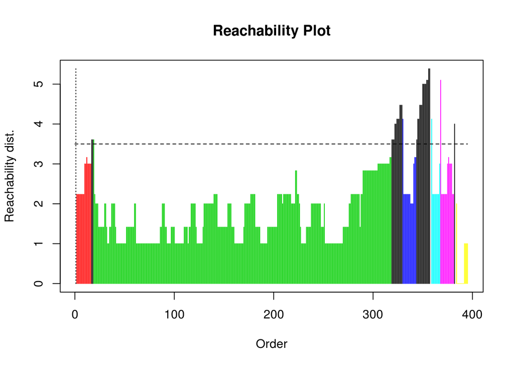

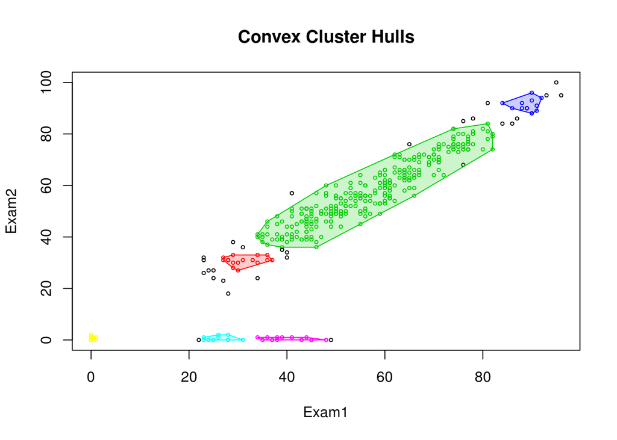

```
## OPTICS ordering/clustering for 395 objects.
## Parameters: minPts = 6, eps = 9.8488578017961, eps_cl = 3.5, xi = NA
## The clustering contains 6 cluster(s) and 29 noise points.
##
##   0   1   2   3   4   5   6
##  29  16 300  14   9  14  13
##
## Available fields: order, reachdist, coredist, predecessor, minPts, eps,
##                   eps_cl, xi, cluster
```

[6 more figures not shown]

```
## OPTICS ordering/clustering for 395 objects.
## Parameters: minPts = 6, eps = 9.8488578017961, eps_cl = 5, xi = NA
## The clustering contains 4 cluster(s) and 4 noise points.
##
##   0   1   2   3   4
##   4 353  10  15  13
##
## Available fields: order, reachdist, coredist, predecessor, minPts, eps,
##                   eps_cl, xi, cluster
```

```r
# Solution for task 3...

stud_optics <- optics(DfStud,  minPts = 6)


for (i in seq(1,5,0.5)) {

  DB_clus = extractDBSCAN(stud_optics,eps_cl = i)

  plot(DB_clus)
  hullplot(DfStud,DB_clus)

  print(DB_clus)


}
```

4. Using the example of the silhouette coefficient, discuss the strengths and weaknesses of internal quality measures. Why are they only conditionally suitable for the comparison between clusterings of different algorithms (e.g. $K$-Means and DBSCAN)? In which cases should they still be used?

```r
# Solution for task 4...
```

Dataset for task 2 and 3:  
http://isgwww.cs.uni-magdeburg.de/cv/lehre/VisAnalytics/material/exercise/datasets/clustering-student-mat.csv